# TeamWork-checkpoint

### 1. 数据集的分析和处理

- 模型需要从这个数据集中学习，从而能够根据所有其他指标，预测用户燃烧的卡路里数量
- 数据集获取出处：https://www.kaggle.com/datasets/yaminh/fitness-track-daily-activity-dataset/data

### 1.2 分析数据集里的数据

- UserID: 用户ID
- Date: 日期
- Total_Distance: 总距离
- Tracker_Distance: 记录器距离
- Logged_Activities_Distance: 记录的活动距离
- Very_Active_Distance: 非常活跃的距离
- Moderately_Active_Distance: 中度活跃的距离
- Light_Active_Distance: 轻度活跃的距离
- Sedentary_Active_Distance: 久坐活跃的距离
- Very_Active_Minutes: 非常活跃的分钟数
- Fairly_Active_Minutes: 相对活跃的分钟数
- Lightly_Active_Minutes: 轻度活跃的分钟数
- Sedentary_Minutes: 久坐的分钟数
- Steps: 步数
- Calories_Burned: 燃烧的卡路里

### 1.3 大作业要求

- 基于scikit-learn、TensorFlow或PyTorch软件包，对数据集进行分类，并可视化。每位同学至少要尝试1种不同的分类方法，并最终比较分类结果

### 1.4 数据集分类方法

- 在机器学习中，处理数据集的分类方法有多种，它们旨在发现数据中的规律并将数据分为不同的类别。以下是一些常见的分类方法：
1. **决策树**：通过递归地将数据集分割成更小的子集，同时在每个决策点处创建一个节点，直到满足停止条件。决策树易于理解和解释，并且能够处理非线性关系。
2. **朴素贝叶斯**：基于贝叶斯定理，假设特征之间相互独立，它利用先验概率和似然概率来计算后验概率，从而进行分类。朴素贝叶斯算法在文本分类等场景下表现良好。
3. **逻辑回归**：尽管命名为回归，但它是处理分类问题的。逻辑回归通过逻辑函数将线性回归的输出映射到分类的响应之间，常用于二分类问题。
4. **K-最近邻(K-NN)**：一种基于实例的学习，通过计算待分类样本与训练集中样本的距离，选取最近的K个邻居，然后根据这些邻居的类别来预测新样本的类别。
5. **支持向量机(SVM)**：寻找不同类别之间的最优边界，即最大化各类之间的间隔。SVM在高维空间的分类问题中表现优异。
6. **随机森林**：由多个决策树组合而成的集成学习算法，可以处理非常高维的数据，并且不容易出现过度拟合的问题。
7. **梯度提升机(GBM)**：另一种强大的集成学习方法，它通过迭代的方式构建模型，每次迭代都致力于纠正之前模型的错误。
8. **神经网络/深度学习**：特别适用于大规模和复杂的数据集，通过多层网络结构学习数据的深层特征表示。
9. **感知机**：最早的人工神经网络之一，可以被视为简化版的前馈神经网络，主要用于模式识别。

以上分类方法各有优势和局限，选择合适的算法需要根据具体问题的性质、数据集的特点以及实际需求来决定。例如，对于小规模数据集，朴素贝叶斯和决策树可能是不错的选择；而对于大规模复杂数据，则可能需要使用如随机森林或神经网络这样的方法。此外，评估分类模型的性能时，通常会考虑准确率、召回率、F1分数、ROC曲线等指标来量化模型的表现。

## 1.5 搞定工作环境

- 首先需要安装python
- 接下来需要为代码创建工作区，又或者创建一个隔离环境(推荐 anaconda)
- 安装需要的包 如 Numpy, Pandas, Matplotlib， Scikit-learn等
- 运行jupyter

## 1.6 获取数据集并进行读取

- 从数据集出处：https://www.kaggle.com/datasets/yaminh/fitness-track-daily-activity-dataset/data 下载csv文件
- 编写读取数据集的函数，如下

```python
import pandas as pd

# Load the dataset
file_path = r'./Activity.csv'
data = pd.read_csv(file_path)

# Display the first few rows of the dataset|
data.head()
```

|  | UserID | Date | Total_Distance | Tracker_Distance | Logged_Activities_Distance | Very_Active_Distance | Moderately_Active_Distance | Light_Active_Distance | Sedentary_Active_Distance | Very_Active_Minutes | Fairly_Active_Minutes | Lightly_Active_Minutes | Sedentary_Minutes | Steps | Calories_Burned |
| --- | --- | --- | --- | --- | --- | --- | --- | --- | --- | --- | --- | --- | --- | --- | --- |
| 0 | 6117666160 | 4/20/2016 | 8.02 | 8.02 | 0.0 | 2.03 | 0.48 | 5.52 | 0.0 | 26 | 10 | 349 | 587 | 10449 | 2536 |
| 1 | 1644430081 | 4/13/2016 | 5.82 | 5.82 | 0.0 | 2.28 | 0.90 | 2.64 | 0.0 | 30 | 16 | 135 | 1259 | 8001 | 2902 |
| 2 | 1927972279 | 4/25/2016 | 0.11 | 0.11 | 0.0 | 0.00 | 0.00 | 0.11 | 0.0 | 0 | 0 | 12 | 1303 | 152 | 2100 |
| 3 | 6117666160 | 4/26/2016 | 7.21 | 7.21 | 0.0 | 0.00 | 0.34 | 6.87 | 0.0 | 0 | 7 | 352 | 1077 | 9543 | 2450 |
| 4 | 4388161847 | 5/9/2016 | 7.86 | 7.86 | 0.0 | 0.34 | 0.73 | 6.79 | 0.0 | 6 | 19 | 258 | 1020 | 10218 | 3013 |

### 2. 利用各种方法对数据集进行分类（分组作业）

## 2.1 廖启帆 分类方式：梯度提升机

- 在开始使用梯度提升机进行分类之前，我们需要确定分类任务的目标变量是什么。由于利用数据集的目的已经确定：即预测用户卡路里的数量。因此，我们的目标是基于其他列（特征）来预测 Calories_Burned（燃烧的卡路里）。我们将使用梯度提升机来完成这个分类任务。
- 首先，我们需要将数据集分为特征（X）和目标（y）。然后，我们将数据集分为训练集和测试集，以便评估模型的性能。
- 由于 Calories_Burned 是一个连续值，我们将使用回归版本的梯度提升机（例如，GradientBoostingRegressor）而不是分类版本的梯度提升机。完成模型的训练后，我们将使用测试集来评估模型的性能，并可视化预测结果与实际结果之间的比较。
- 具体实现代码和可视化结果如下

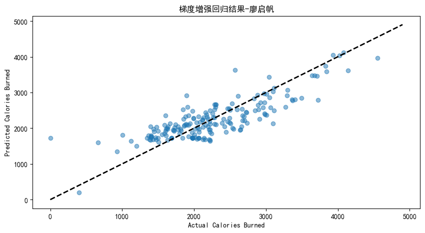

```
(161514.01225063077, 0.6809569751610008)
```

```python
from sklearn.model_selection import train_test_split
from sklearn.ensemble import GradientBoostingRegressor
from sklearn.metrics import mean_squared_error, r2_score
import matplotlib.pyplot as plt

# Remove non-numeric columns and the target column from the feature list
non_numeric_columns = ['UserID', 'Date']
features = data.columns.drop(['Calories_Burned'] + non_numeric_columns)

# Split the data into features and target
X = data[features]
y = data['Calories_Burned']

# Split the data into training and testing sets
X_train, X_test, y_train, y_test = train_test_split(X, y, test_size=0.2, random_state=42)

# Initialize the Gradient Boosting Regressor
gb_regressor = GradientBoostingRegressor(n_estimators=100, learning_rate=0.1, random_state=42)

# Train the model
gb_regressor.fit(X_train, y_train)

# Predict on the test set
y_pred = gb_regressor.predict(X_test)

# Calculate the performance metrics
mse = mean_squared_error(y_test, y_pred)
r2 = r2_score(y_test, y_pred)

# Visualize the results
plt.figure(figsize=(10, 5))
plt.scatter(y_test, y_pred, alpha=0.5)
plt.xlabel('Actual Calories Burned')
plt.ylabel('Predicted Calories Burned')
plt.rcParams['font.sans-serif']=['SimHei']
plt.rcParams['axes.unicode_minus']=False
plt.title('梯度增强回归结果-廖启帆')
plt.plot([y.min(), y.max()], [y.min(), y.max()], 'k--', lw=2)
plt.show()

mse, r2
```

模型的性能指标如下：

- 均方误差 (MSE): 161,514.01
- 决定系数 (R²): 0.681

均方误差（MSE）是衡量预测值与实际值之间差异的指标，值越低表示模型性能越好。决定系数（R²）表示模型对数据拟合的好坏，值越接近1表示模型拟合度越高。

从可视化结果来看，大部分的点都落在对角线附近，表明模型的预测值与实际值较为接近。但是也有一些点离对角线较远，说明在这些情况下模型的预测并不十分准确。

## 2.2 蓝骐岳 分类方法：决策树

## 2.2.1 加载数据

```python
import pandas as pd

# Load the dataset
file_path = r'./Activity.csv'
dataset = pd.read_csv(file_path)

# Display the first few rows of the dataset
dataset.head()
```

|  | UserID | Date | Total_Distance | Tracker_Distance | Logged_Activities_Distance | Very_Active_Distance | Moderately_Active_Distance | Light_Active_Distance | Sedentary_Active_Distance | Very_Active_Minutes | Fairly_Active_Minutes | Lightly_Active_Minutes | Sedentary_Minutes | Steps | Calories_Burned |
| --- | --- | --- | --- | --- | --- | --- | --- | --- | --- | --- | --- | --- | --- | --- | --- |
| 0 | 6117666160 | 4/20/2016 | 8.02 | 8.02 | 0.0 | 2.03 | 0.48 | 5.52 | 0.0 | 26 | 10 | 349 | 587 | 10449 | 2536 |
| 1 | 1644430081 | 4/13/2016 | 5.82 | 5.82 | 0.0 | 2.28 | 0.90 | 2.64 | 0.0 | 30 | 16 | 135 | 1259 | 8001 | 2902 |
| 2 | 1927972279 | 4/25/2016 | 0.11 | 0.11 | 0.0 | 0.00 | 0.00 | 0.11 | 0.0 | 0 | 0 | 12 | 1303 | 152 | 2100 |
| 3 | 6117666160 | 4/26/2016 | 7.21 | 7.21 | 0.0 | 0.00 | 0.34 | 6.87 | 0.0 | 0 | 7 | 352 | 1077 | 9543 | 2450 |
| 4 | 4388161847 | 5/9/2016 | 7.86 | 7.86 | 0.0 | 0.34 | 0.73 | 6.79 | 0.0 | 6 | 19 | 258 | 1020 | 10218 | 3013 |

- 此处使用 “Calories_Burned” 作为目标变量进行分类。
- 为了进行分类，需要将 “Calories_Burned” 转换为一个分类变量。
- 可以使用一个阈值来将数据分为两个类别：例如，“Calories_Burned” 高于某个值的为一类，低于这个值的为另一类。

## 2.2.2 查看 “Calories_Burned” 的分布情况，以帮助选择一个合适的阈值。

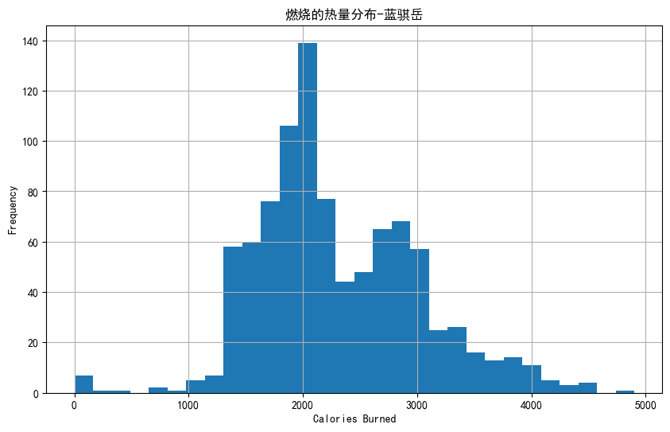

```python
import matplotlib.pyplot as plt

# Plotting the distribution of 'Calories_Burned'
plt.figure(figsize=(10, 6))
dataset['Calories_Burned'].hist(bins=30)
plt.rcParams['font.sans-serif']=['SimHei']
plt.rcParams['axes.unicode_minus']=False
plt.title('燃烧的热量分布-蓝骐岳')
plt.xlabel('Calories Burned')
plt.ylabel('Frequency')
plt.grid(True)
plt.show()
```

- 从 “Calories_Burned” 的分布图中，可以看到大部分的数据集中在较低的卡路里消耗范围内，而较高卡路里消耗的数据较少。为了选择一个合适的阈值，可以考虑使用中位数或者平均值作为划分点。

## 2.2.3 使用中位数作为阈值来将数据分为两类，然后进行决策树的训练和可视化。

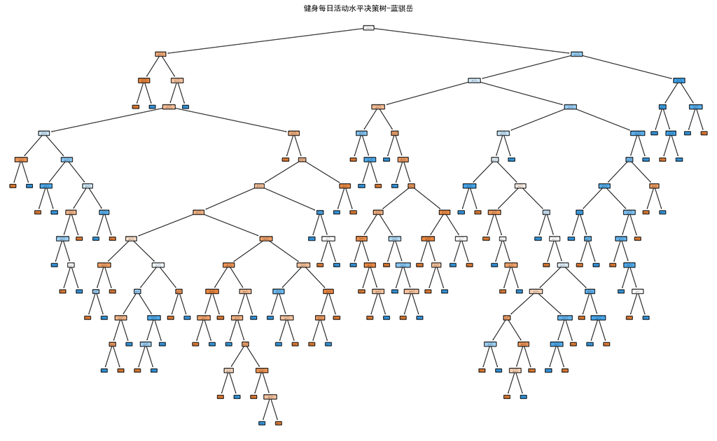

```
0.7198581560283688
```

```python
from sklearn.model_selection import train_test_split
from sklearn.tree import DecisionTreeClassifier, plot_tree
from sklearn.metrics import accuracy_score
import numpy as np

# Using median as the threshold to create a binary target variable
median_calories = dataset['Calories_Burned'].median()
binary_target = np.where(dataset['Calories_Burned'] > median_calories, 1, 0)

# Splitting the dataset into features and target variable
features = dataset.drop(['Calories_Burned', 'UserID', 'Date'], axis=1)
target = binary_target

# Splitting the data into training and testing sets
X_train, X_test, y_train, y_test = train_test_split(features, target, test_size=0.3, random_state=42)

# Training the decision tree classifier
clf = DecisionTreeClassifier(random_state=42)
clf.fit(X_train, y_train)

# Predicting on the test set
y_pred = clf.predict(X_test)

# Calculating the accuracy
accuracy = accuracy_score(y_test, y_pred)

# Visualizing the decision tree
plt.figure(figsize=(20, 12))
plot_tree(clf, feature_names=features.columns, filled=True, rounded=True)
plt.rcParams['font.sans-serif']=['SimHei']
plt.rcParams['axes.unicode_minus']=False
plt.title('健身每日活动水平决策树-蓝骐岳')
plt.show()

accuracy
```

## 2.2.4 准确度分许

- 决策树分类器的准确率为约 71.99%。从可视化的决策树中，我们可以看到决策树的结构以及用于分类的特征。
- 每个节点显示了用于分割数据的特征，以及该节点中数据的类别分布。节点旁边的数字表示决策的条件。例如，如果一个节点的条件是 “Total_Distance <= 4.95”，则表示该节点将数据集分为 “Total_Distance” 小于或等于 4.95 的数据，和大于 4.95 的数据。

## 2.3 唐倩华 分类方法：随机森林

### 2.3.1加载数据。

```python
import pandas as pd
# Load the CSV data into a DataFrame
file_path = 'Activity.csv'
data = pd.read_csv(file_path)
data.head()
```

|  | UserID | Date | Total_Distance | Tracker_Distance | Logged_Activities_Distance | Very_Active_Distance | Moderately_Active_Distance | Light_Active_Distance | Sedentary_Active_Distance | Very_Active_Minutes | Fairly_Active_Minutes | Lightly_Active_Minutes | Sedentary_Minutes | Steps | Calories_Burned |
| --- | --- | --- | --- | --- | --- | --- | --- | --- | --- | --- | --- | --- | --- | --- | --- |
| 0 | 6117666160 | 4/20/2016 | 8.02 | 8.02 | 0.0 | 2.03 | 0.48 | 5.52 | 0.0 | 26 | 10 | 349 | 587 | 10449 | 2536 |
| 1 | 1644430081 | 4/13/2016 | 5.82 | 5.82 | 0.0 | 2.28 | 0.90 | 2.64 | 0.0 | 30 | 16 | 135 | 1259 | 8001 | 2902 |
| 2 | 1927972279 | 4/25/2016 | 0.11 | 0.11 | 0.0 | 0.00 | 0.00 | 0.11 | 0.0 | 0 | 0 | 12 | 1303 | 152 | 2100 |
| 3 | 6117666160 | 4/26/2016 | 7.21 | 7.21 | 0.0 | 0.00 | 0.34 | 6.87 | 0.0 | 0 | 7 | 352 | 1077 | 9543 | 2450 |
| 4 | 4388161847 | 5/9/2016 | 7.86 | 7.86 | 0.0 | 0.34 | 0.73 | 6.79 | 0.0 | 6 | 19 | 258 | 1020 | 10218 | 3013 |

### 2.3.2使用 scikit-learn 来实现随机森林，并进行分类和可视化。

- 首先准备数据，将它们分为特征（X）和目标（y）
- 将数据集分为训练集和测试集，训练随机森林分类器，并在测试集上评估其性能。
- 最后，我们将可视化分类结果。

```python
from sklearn.model_selection import train_test_split
import pandas as pd
import numpy as np
from sklearn.ensemble import RandomForestClassifier
from sklearn.metrics import accuracy_score, classification_report, confusion_matrix
import matplotlib.pyplot as plt
import seaborn as sns
# Load the CSV data into a DataFrame
file_path = 'Activity.csv'
data = pd.read_csv(file_path)

# prepare the data
data['Date'] = pd.to_datetime(data['Date'])
data['Day_of_Week'] = data['Date'].dt.dayofweek
data_numeric = data.select_dtypes(include=[np.number]).dropna()
data_numeric['Calories_Burned_Cat'] = pd.qcut(data_numeric['Calories_Burned'], 2, labels=['Low', 'High'])
X = data_numeric.drop(columns=['Calories_Burned', 'Calories_Burned_Cat'])
y = data_numeric['Calories_Burned_Cat']

# Split dataset
X_train, X_test, y_train, y_test = train_test_split(X, y, test_size=0.3, random_state=42)

# Training a Random Forest Classifier
clf = RandomForestClassifier(random_state=42)
clf.fit(X_train, y_train)

# Predictive test set
y_pred = clf.predict(X_test)
# Calculation accuracy
accuracy = accuracy_score(y_test, y_pred)
classification_rep = classification_report(y_test, y_pred)

# Print accuracy and classification reports
print("Accuracy:", accuracy)
print("\nClassification Report:\n", classification_rep)
```

```
Accuracy: 0.8546099290780141

Classification Report:
               precision    recall  f1-score   support

        High       0.89      0.82      0.85       144
         Low       0.83      0.89      0.86       138

    accuracy                           0.85       282
   macro avg       0.86      0.86      0.85       282
weighted avg       0.86      0.85      0.85       282
```

随机森林的方法准确率大约为85%。

### 2.3.3使用混淆矩阵进行可视化

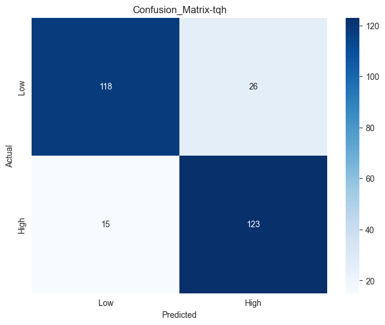

```python
# Generate confusion matrix chart
cm = confusion_matrix(y_test, y_pred)
plt.figure(figsize=(8, 6))
sns.heatmap(cm, annot=True, fmt='d', cmap='Blues', xticklabels=['Low', 'High'], yticklabels=['Low', 'High'])
plt.xlabel('Predicted')
plt.ylabel('Actual')
plt.title('Confusion_Matrix-tqh')
plt.show()
```

混淆矩阵的图表展示了模型在测试集上的预测结果。每一行代表一个实际的类别，而每一列代表一个预测的类别。对角线上的数字表示模型正确预测的实例数量，而非对角线上的数字表示模型错误预测的实例数量。

## 2.4 张文轩 分类方法：逻辑回归

### 2.4.1加载数据并查看前几行。

```python
import pandas as pd

# Load the CSV data into a DataFrame
file_path = './Activity.csv'
data = pd.read_csv(file_path)

# Display the first few rows of the dataset
data.head()
```

|  | UserID | Date | Total_Distance | Tracker_Distance | Logged_Activities_Distance | Very_Active_Distance | Moderately_Active_Distance | Light_Active_Distance | Sedentary_Active_Distance | Very_Active_Minutes | Fairly_Active_Minutes | Lightly_Active_Minutes | Sedentary_Minutes | Steps | Calories_Burned |
| --- | --- | --- | --- | --- | --- | --- | --- | --- | --- | --- | --- | --- | --- | --- | --- |
| 0 | 6117666160 | 4/20/2016 | 8.02 | 8.02 | 0.0 | 2.03 | 0.48 | 5.52 | 0.0 | 26 | 10 | 349 | 587 | 10449 | 2536 |
| 1 | 1644430081 | 4/13/2016 | 5.82 | 5.82 | 0.0 | 2.28 | 0.90 | 2.64 | 0.0 | 30 | 16 | 135 | 1259 | 8001 | 2902 |
| 2 | 1927972279 | 4/25/2016 | 0.11 | 0.11 | 0.0 | 0.00 | 0.00 | 0.11 | 0.0 | 0 | 0 | 12 | 1303 | 152 | 2100 |
| 3 | 6117666160 | 4/26/2016 | 7.21 | 7.21 | 0.0 | 0.00 | 0.34 | 6.87 | 0.0 | 0 | 7 | 352 | 1077 | 9543 | 2450 |
| 4 | 4388161847 | 5/9/2016 | 7.86 | 7.86 | 0.0 | 0.34 | 0.73 | 6.79 | 0.0 | 6 | 19 | 258 | 1020 | 10218 | 3013 |

在进行逻辑回归之前，需要确定一个分类任务的目标变量（通常是二分类）。

由于数据集没有直接的二元标签，我们需要根据数据集创建一个或选择一个特征作为目标变量。

### 2.4.2使用 scikit-learn 来实现逻辑回归，并进行分类和可视化。

- 首先，我们将数据集分为特征（X）和目标（y）。
- 然后，我们将进行数据预处理，包括将分类特征编码，标准化数值特征，并分割数据集为训练集和测试集。
- 最后，我们将使用逻辑回归模型进行训练，并对测试集进行预测，然后可视化结果。让我们开始这个过程。

```python
from sklearn.model_selection import train_test_split
from sklearn.linear_model import LogisticRegression
from sklearn.metrics import accuracy_score, confusion_matrix, classification_report
import matplotlib.pyplot as plt
import seaborn as sns
from sklearn.preprocessing import StandardScaler

# Create a binary target variable based on 'Calories_Burned'
# Here, we will classify 'Calories_Burned' above average as 1 and below average as 0
average_calories = data['Calories_Burned'].mean()
data['Above_Average'] = data['Calories_Burned'].apply(lambda x: 1 if x > average_calories else 0)

# Selecting features and target variable
# For simplicity, we are selecting a subset of features that could be relevant for predicting 'Above_Average'
features = ['Total_Distance', 'Tracker_Distance', 'Very_Active_Distance',
            'Moderately_Active_Distance', 'Light_Active_Distance', 'Steps']
X = data[features]
y = data['Above_Average']

# Splitting the dataset into training and testing sets
X_train, X_test, y_train, y_test = train_test_split(X, y, test_size=0.2, random_state=42)

# Standardize the features
scaler = StandardScaler()
X_train_scaled = scaler.fit_transform(X_train)
X_test_scaled = scaler.transform(X_test)

# Initialize and train the logistic regression model
logreg = LogisticRegression()
logreg.fit(X_train_scaled, y_train)

# Predictions on the test set
y_pred = logreg.predict(X_test_scaled)

# Calculate the accuracy
accuracy = accuracy_score(y_test, y_pred)
accuracy
```

```
0.8191489361702128
```

逻辑回归模型在测试集上的准确率为约 81.92%。

### 2.4.3查看混淆矩阵和分类报告,然后可视化混淆矩阵。

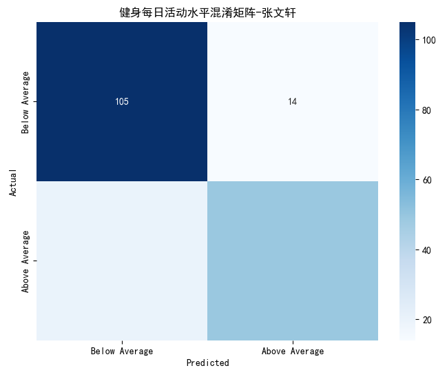

```
              precision    recall  f1-score   support

           0       0.84      0.88      0.86       119
           1       0.78      0.71      0.74        69

    accuracy                           0.82       188
   macro avg       0.81      0.80      0.80       188
weighted avg       0.82      0.82      0.82       188
```

```python
# Generate the confusion matrix
conf_matrix = confusion_matrix(y_test, y_pred)

# Generate the classification report
class_report = classification_report(y_test, y_pred)

# Visualize the confusion matrix using a heatmap
plt.figure(figsize=(8, 6))
sns.heatmap(conf_matrix, annot=True, fmt='d', cmap='Blues',
            xticklabels=['Below Average', 'Above Average'],
            yticklabels=['Below Average', 'Above Average'])
plt.ylabel('Actual')
plt.xlabel('Predicted')
plt.rcParams['font.sans-serif']=['SimHei']
plt.rcParams['axes.unicode_minus']=False
plt.title('健身每日活动水平混淆矩阵-张文轩')
plt.show()

conf_matrix
print(class_report)
```

### 2.4.4混淆矩阵和分类报告提供了关于模型性能的详细信息：

#### 混淆矩阵：

- 真正 (True Positive, TP): 预测为正类且实际为正类的数量
- 假正 (False Positive, FP): 预测为正类但实际为负类的数量
- 假负 (False Negative, FN): 预测为负类但实际为正类的数量
- 真负 (True Negative, TN): 预测为负类且实际为负类的数量

#### 分类报告：

- Precision (精确度): 模型预测为正类的样本中实际为正类的比例
- Recall (召回率): 实际为正类的样本中模型预测为正类的比例
- F1-score: 精确度和召回率的调和平均数
- Support: 每个类别的样本数量

#### 从混淆矩阵中我们可以看到：

- 105个实际低于平均值的样本被正确预测为低于平均值。
- 14个实际低于平均值的样本被错误预测为高于平均值。
- 20个实际高于平均值的样本被错误预测为低于平均值。
- 49个实际高于平均值的样本被正确预测为高于平均值。

分类报告显示，模型在低于平均值的类别上的精确度和召回率较高，而在高于平均值的类别上的性能稍差。

以上是基于 scikit-learn 的逻辑回归分类过程及其性能评估。

## 2.5 万天一 分类方法：神经网络

- 在开始使用神经网络进行分类之前，我们需要知道对哪个目标变量进行分类。我们的目标是预测 Calories_Burned，即燃烧的卡路里数。为此，我们将使用神经网络来建立一个回归模型，

因为 Calories_Burned 是一个连续值。

- 下面是接下来的步骤：
- 数据预处理：我们将处理数据，包括填充缺失值（如果有的话）、编码分类特征（如果有的话）、标准化数值特征以及分割数据集为训练集和测试集。
- 建立神经网络模型：我们将使用一个简单的神经网络架构来训练模型。
- 训练模型：使用训练集来训练模型。
- 评估模型：使用测试集来评估模型的性能。
- 可视化结果：我们将可视化模型的预测结果与实际结果进行比较。
- 在我们对模型进行可视化之前，我们需要使用训练好的模型对测试集进行预测，并将这些预测与实际值进行比较。这将帮助我们了解模型的表现。然后，我们可以将这些预测结果可视化。
- 具体实现代码和可视化结果如下

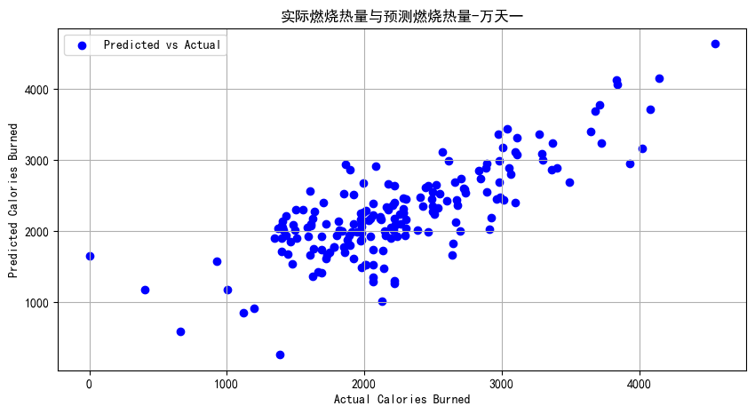

```python
import pandas as pd
from sklearn.model_selection import train_test_split
from sklearn.preprocessing import StandardScaler, OneHotEncoder
from sklearn.impute import SimpleImputer
from sklearn.compose import ColumnTransformer
from sklearn.pipeline import Pipeline
from sklearn.neural_network import MLPRegressor
import matplotlib.pyplot as plt

# Load the dataset
file_path = "./Activity.csv"
data = pd.read_csv(file_path)

# Separate features and target variable
X = data.drop('Calories_Burned', axis=1)
y = data['Calories_Burned']

# Split the data into training and test sets
X_train, X_test, y_train, y_test = train_test_split(X, y, test_size=0.2, random_state=42)

# Identify categorical and numerical columns
categorical_cols = X_train.select_dtypes(include=['object']).columns
numerical_cols = X_train.select_dtypes(exclude=['object']).columns

# Create pipelines for preprocessing
numerical_transformer = Pipeline(steps=[
    ('imputer', SimpleImputer(strategy='mean')),  # Fill missing values with the mean
    ('scaler', StandardScaler())])  # Standardize the data

categorical_transformer = Pipeline(steps=[
    ('imputer', SimpleImputer(strategy='most_frequent')),  # Fill missing values with the most frequent value
    ('onehot', OneHotEncoder(handle_unknown='ignore'))])  # One-hot encode the categorical features

# Combine the pipelines
preprocessor = ColumnTransformer(
    transformers=[
        ('num', numerical_transformer, numerical_cols),
        ('cat', categorical_transformer, categorical_cols)])

# Preprocess the training data
X_train_preprocessed = preprocessor.fit_transform(X_train)
X_test_preprocessed = preprocessor.transform(X_test)

# Create an MLPRegressor model
mlp_model = MLPRegressor(hidden_layer_sizes=(64, 32), activation='relu', solver='adam', max_iter=10000, random_state=42)

# Train the model on the preprocessed training data
mlp_model.fit(X_train_preprocessed, y_train)

# Make predictions on the preprocessed test data
y_pred = mlp_model.predict(X_test_preprocessed)

# Plot the actual vs predicted values
plt.figure(figsize=(10, 5))
plt.scatter(y_test, y_pred, c='blue', label='Predicted vs Actual')
plt.xlabel('Actual Calories Burned')
plt.ylabel('Predicted Calories Burned')
plt.rcParams['font.sans-serif']=['SimHei']
plt.rcParams['axes.unicode_minus']=False
plt.title('实际燃烧热量与预测燃烧热量-万天一')
plt.legend()
plt.grid(True)
plt.show()
```

## 2.6 冯满星 分类方法：Lass回归

## 2.6.1 加载数据

```python
import pandas as pd

# Load the CSV data into a DataFrame
file_path = './Activity.csv'
data = pd.read_csv(file_path)

# Display the first few rows of the dataset
data.head()
```

|  | UserID | Date | Total_Distance | Tracker_Distance | Logged_Activities_Distance | Very_Active_Distance | Moderately_Active_Distance | Light_Active_Distance | Sedentary_Active_Distance | Very_Active_Minutes | Fairly_Active_Minutes | Lightly_Active_Minutes | Sedentary_Minutes | Steps | Calories_Burned |
| --- | --- | --- | --- | --- | --- | --- | --- | --- | --- | --- | --- | --- | --- | --- | --- |
| 0 | 6117666160 | 4/20/2016 | 8.02 | 8.02 | 0.0 | 2.03 | 0.48 | 5.52 | 0.0 | 26 | 10 | 349 | 587 | 10449 | 2536 |
| 1 | 1644430081 | 4/13/2016 | 5.82 | 5.82 | 0.0 | 2.28 | 0.90 | 2.64 | 0.0 | 30 | 16 | 135 | 1259 | 8001 | 2902 |
| 2 | 1927972279 | 4/25/2016 | 0.11 | 0.11 | 0.0 | 0.00 | 0.00 | 0.11 | 0.0 | 0 | 0 | 12 | 1303 | 152 | 2100 |
| 3 | 6117666160 | 4/26/2016 | 7.21 | 7.21 | 0.0 | 0.00 | 0.34 | 6.87 | 0.0 | 0 | 7 | 352 | 1077 | 9543 | 2450 |
| 4 | 4388161847 | 5/9/2016 | 7.86 | 7.86 | 0.0 | 0.34 | 0.73 | 6.79 | 0.0 | 6 | 19 | 258 | 1020 | 10218 | 3013 |

数据集包含了多个特征，其中 “Calories_Burned” 是我们的目标变量。在应用Lasso回归之前，我们需要进行一些数据预处理步骤，例如将非数值型特征转换为数值型特征，标准化数据，以及拆分数据集为训练集和测试集。

接下来，进行以下步骤：

- 检查缺失值并处理。
- 将非数值型特征转换为数值型特征（如果有的话）。
- 分割数据为特征（X）和目标变量（y）。
- 分割数据集为训练集和测试集。
- 对特征进行标准化处理。
- 应用Lasso回归模型。
- 可视化结果。

## 2.6.2 检查数据集中是否有缺失值。

```python
# Check for missing values in the dataset
missing_values = data.isnull().sum()

missing_values
```

```
UserID                        0
Date                          0
Total_Distance                0
Tracker_Distance              0
Logged_Activities_Distance    0
Very_Active_Distance          0
Moderately_Active_Distance    0
Light_Active_Distance         0
Sedentary_Active_Distance     0
Very_Active_Minutes           0
Fairly_Active_Minutes         0
Lightly_Active_Minutes        0
Sedentary_Minutes             0
Steps                         0
Calories_Burned               0
dtype: int64
```

数据集中没有缺失值，可以直接进行下一步。

## 2.6.3 处理 “Date” 特征。

```python
# Convert the 'Date' column to datetime and extract year, month, and day
data['Date'] = pd.to_datetime(data['Date'])
data['Year'] = data['Date'].dt.year
data['Month'] = data['Date'].dt.month
data['Day'] = data['Date'].dt.day

# Drop the original 'Date' column
data.drop('Date', axis=1, inplace=True)

# Display the first few rows of the dataset after processing
data.head()
```

|  | UserID | Total_Distance | Tracker_Distance | Logged_Activities_Distance | Very_Active_Distance | Moderately_Active_Distance | Light_Active_Distance | Sedentary_Active_Distance | Very_Active_Minutes | Fairly_Active_Minutes | Lightly_Active_Minutes | Sedentary_Minutes | Steps | Calories_Burned | Year | Month | Day |
| --- | --- | --- | --- | --- | --- | --- | --- | --- | --- | --- | --- | --- | --- | --- | --- | --- | --- |
| 0 | 6117666160 | 8.02 | 8.02 | 0.0 | 2.03 | 0.48 | 5.52 | 0.0 | 26 | 10 | 349 | 587 | 10449 | 2536 | 2016 | 4 | 20 |
| 1 | 1644430081 | 5.82 | 5.82 | 0.0 | 2.28 | 0.90 | 2.64 | 0.0 | 30 | 16 | 135 | 1259 | 8001 | 2902 | 2016 | 4 | 13 |
| 2 | 1927972279 | 0.11 | 0.11 | 0.0 | 0.00 | 0.00 | 0.11 | 0.0 | 0 | 0 | 12 | 1303 | 152 | 2100 | 2016 | 4 | 25 |
| 3 | 6117666160 | 7.21 | 7.21 | 0.0 | 0.00 | 0.34 | 6.87 | 0.0 | 0 | 7 | 352 | 1077 | 9543 | 2450 | 2016 | 4 | 26 |
| 4 | 4388161847 | 7.86 | 7.86 | 0.0 | 0.34 | 0.73 | 6.79 | 0.0 | 6 | 19 | 258 | 1020 | 10218 | 3013 | 2016 | 5 | 9 |

## 2.6.4 使用独热编码（One-Hot Encoding）来处理 “UserID” 这一类别特征。

```python
# Apply one-hot encoding to the 'UserID' column
data_encoded = pd.get_dummies(data, columns=['UserID'])

# Define the features (X) and the target variable (y) again after encoding
X = data_encoded.drop('Calories_Burned', axis=1)
y = data_encoded['Calories_Burned']

# Split the dataset into a training set and a test set again
X_train, X_test, y_train, y_test = train_test_split(X, y, test_size=0.2, random_state=42)

# Standardize the feature matrix again
scaler = StandardScaler()
X_train_scaled = scaler.fit_transform(X_train)
X_test_scaled = scaler.transform(X_test)

# Show the first few rows of the standardized training data after encoding
X_train_scaled[:5, :]
```

```
array([[ 0.64226323,  0.6490234 , -0.18319545, -0.16387011, -0.41311161,
         1.65906634, -0.21350216, -0.13942135, -0.47940027,  0.44425506,
         0.61508209,  0.5751544 ,  0.        ,  1.39607292, -0.92915676,
        -0.18924236, -0.18924236, -0.16949268, -0.19665715, -0.18156826,
        -0.16949268, -0.18924236, -0.17360008, -0.13773231, -0.19665715,
        -0.13773231, -0.17360008, -0.16949268, -0.05163978, -0.18924236,
        -0.18156826, -0.18924236, -0.18924236, -0.19665715, -0.18543974,
        -0.19298026, -0.18924236, -0.18543974, -0.16099961, -0.17762339,
        -0.1652949 , -0.18924236, -0.19665715, -0.14266318, -0.17762339,
        -0.18924236, -0.1652949 ,  5.50757055],
       [ 0.42175246,  0.42752027, -0.18319545, -0.55997941, -0.63494818,
         1.87355574, -0.21350216, -0.64750647, -0.67669621,  2.41986797,
        -1.69203305,  0.3606578 ,  0.        , -0.71629496,  1.52497329,
        -0.18924236, -0.18924236, -0.16949268, -0.19665715, -0.18156826,
        -0.16949268, -0.18924236, -0.17360008, -0.13773231, -0.19665715,
        -0.13773231, -0.17360008, -0.16949268, -0.05163978, -0.18924236,
        -0.18156826, -0.18924236, -0.18924236, -0.19665715, -0.18543974,
        -0.19298026,  5.28422908, -0.18543974, -0.16099961, -0.17762339,
        -0.1652949 , -0.18924236, -0.19665715, -0.14266318, -0.17762339,
        -0.18924236, -0.1652949 , -0.18156826],
       [-1.41330287, -1.41579331, -0.18319545, -0.55997941, -0.63494818,
        -1.65577318, -0.21350216, -0.64750647, -0.67669621, -1.79660219,
         1.49809306, -1.52001068,  0.        , -0.71629496, -0.34484008,
        -0.18924236, -0.18924236, -0.16949268, -0.19665715, -0.18156826,
        -0.16949268, -0.18924236, -0.17360008, -0.13773231, -0.19665715,
        -0.13773231, -0.17360008,  5.89995964, -0.05163978, -0.18924236,
        -0.18156826, -0.18924236, -0.18924236, -0.19665715, -0.18543974,
        -0.19298026, -0.18924236, -0.18543974, -0.16099961, -0.17762339,
        -0.1652949 , -0.18924236, -0.19665715, -0.14266318, -0.17762339,
        -0.18924236, -0.1652949 , -0.18156826],
       [-0.13839555, -0.13514856, -0.18319545,  0.40095234, -0.6016727 ,
        -0.49557933, -0.21350216,  0.30888904, -0.62737223, -0.0222091 ,
        -0.49698061, -0.09990207,  0.        , -0.71629496,  1.29124661,
        -0.18924236, -0.18924236, -0.16949268, -0.19665715, -0.18156826,
        -0.16949268, -0.18924236, -0.17360008, -0.13773231, -0.19665715,
        -0.13773231, -0.17360008, -0.16949268, -0.05163978, -0.18924236,
        -0.18156826,  5.28422908, -0.18924236, -0.19665715, -0.18543974,
        -0.19298026, -0.18924236, -0.18543974, -0.16099961, -0.17762339,
        -0.1652949 , -0.18924236, -0.19665715, -0.14266318, -0.17762339,
        -0.18924236, -0.1652949 , -0.18156826],
       [ 1.27084587,  1.28043483, -0.18319545, -0.55997941, -0.32437698,
         3.36523369, -0.21350216, -0.64750647, -0.3807523 ,  2.89547849,
        -0.22477422,  1.22864356,  0.        , -0.71629496, -0.11111341,
        -0.18924236, -0.18924236, -0.16949268, -0.19665715, -0.18156826,
        -0.16949268, -0.18924236, -0.17360008, -0.13773231, -0.19665715,
        -0.13773231, -0.17360008, -0.16949268, -0.05163978, -0.18924236,
        -0.18156826, -0.18924236, -0.18924236, -0.19665715, -0.18543974,
        -0.19298026,  5.28422908, -0.18543974, -0.16099961, -0.17762339,
        -0.1652949 , -0.18924236, -0.19665715, -0.14266318, -0.17762339,
        -0.18924236, -0.1652949 , -0.18156826]])
```

## 2.6.5 进行Lasso回归模型的训练。

```python
from sklearn.linear_model import Lasso
from sklearn.metrics import mean_squared_error, r2_score

# Initialize the Lasso regression model
lasso = Lasso(alpha=0.1)  # alpha is the regularization strength

# Fit the model to the training data
lasso.fit(X_train_scaled, y_train)

# Make predictions on the test data
y_pred = lasso.predict(X_test_scaled)

# Calculate the mean squared error and the R^2 score
mse = mean_squared_error(y_test, y_pred)
r2 = r2_score(y_test, y_pred)

# Show the coefficients of the model
coefficients = lasso.coef_

# Output the mean squared error, R^2 score, and some of the coefficients
mse, r2, coefficients[:5], coefficients[-5:]  # Show first 5 and last 5 coefficients
```

```
(39010.584015890956,
 0.9229413315183299,
 array([1158.10739249,   90.54111004,   -3.02794963, -542.13054327,
        -212.7371103 ]),
 array([-53.85680178, 145.36256064,  48.6522894 ,  32.46182128,
         43.84347453]))
```

Lasso回归模型已经训练完成。模型的性能可以通过以下指标进行评估：

- 均方误差 (MSE): 39010.58
- R² 分数: 0.92

这些结果表明模型具有相当好的性能。均方误差表示预测值与实际值之间的差异，而R²分数（决定系数）是衡量模型解释响应变量变异程度的指标，其值接近1表示模型解释程度越高。

## 2.6.6 通过可视化来进一步查看模型的预测结果和实际值之间的关系

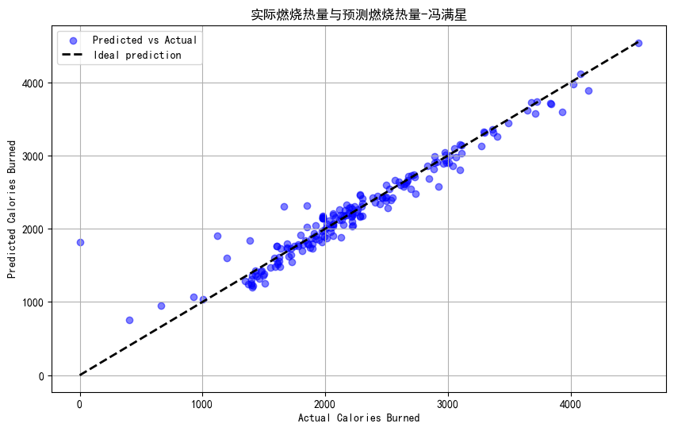

```python
import matplotlib.pyplot as plt

# Scatter plot of actual vs. predicted values
plt.figure(figsize=(10, 6))
plt.scatter(y_test, y_pred, color='blue', alpha=0.5, label='Predicted vs Actual')
plt.plot([y_test.min(), y_test.max()], [y_test.min(), y_test.max()], 'k--', lw=2, label='Ideal prediction')
plt.xlabel('Actual Calories Burned')
plt.ylabel('Predicted Calories Burned')
plt.rcParams['font.sans-serif']=['SimHei']
plt.rcParams['axes.unicode_minus']=False
plt.title('实际燃烧热量与预测燃烧热量-冯满星')
plt.legend()
plt.grid(True)
plt.show()
```

从散点图中可以看出，Lasso回归模型的预测值与实际值之间有相当好的对应关系。大部分数据点都紧密地围绕在对角线上，这表明模型的预测效果是准确的。